# Feature and Target Engineering

```r
library(dplyr)
library(ggplot2)
library(visdat)

library(caret)
library(recipes)

# ames housing data
ames <- AmesHousing::make_ames()

set.seed(123)

# stratified sampling with the rsample package
split <- rsample::initial_split(ames, prop = 0.7, strata = "Sale_Price")
ames_train <- rsample::training(split)
ames_test <- rsample::testing(split)
```

## Target Engineering

There are two main approaches to help correct for positively skewed target variables.

**1. Normalize with log-transformation**

```r
ames_recipe <- recipe(Sale_Price ~ ., data = ames_train) %>%
  step_log(all_outcomes())

ames_recipe
```

```
## Recipe
##
## Inputs:
##
##       role #variables
##    outcome          1
##  predictor         80
##
## Operations:
##
## Log transformation on all_outcomes()
```

If the response has negative values or zeros then log transform will produce `NaNs` and `-Infs` respectively. If the nonpositive response values are small (in between -0.99 to 0), then using `log1p()` (which adds 1 prior to applying log transform) could be an option. (similarly there’s an `offset` argument for `step_log`)

```r
recipe(Sale_Price ~ ., data = ames_train) %>%
  step_log(all_outcomes(), offset = 1)
```

```
## Recipe
##
## Inputs:
##
##       role #variables
##    outcome          1
##  predictor         80
##
## Operations:
##
## Log transformation on all_outcomes()
```

But if the data contains neg values $\le -1$, we need to use Yeo-Johnson transformation.

**2. Use a Box-Cox transformation**

Its more flexible than log-transformation. Yeo-Johnson transformation is very similar to Box-cox, but doesn’t require the input variables to be strictly positive.

```r
ames_recipe <- recipe(Sale_Price ~ ., data = ames_train) %>%
  step_BoxCox(all_outcomes())
```

```r
recipe(Sale_Price ~ ., data = ames_train) %>%
  step_YeoJohnson(all_outcomes())
```

```
## Recipe
##
## Inputs:
##
##       role #variables
##    outcome          1
##  predictor         80
##
## Operations:
##
## Yeo-Johnson transformation on all_outcomes()
```

## Dealing with Missingness

Data can missing for many different reasons.

- **Informative missingness**: Implies a structural cause for data missing and happens due to defficiencies how the data was collected or due to abnormalities in the observational environment. So, such missingness can provide some insight. we can label such missing values as a unique category (such as, `"None"`).
- **Missingness at random (MAR)**: missing values occur independently of the data collection process and depending on the data-size we may impute or delete them.
- **GLM models, neural network, svm cannot handles missingness**
- **Tree based models have built-in procedure to handle missingness**

But its better to handle missingness before the modelling process.

### Visualizing missing values

```r
sum(is.na(AmesHousing::ames_raw))
```

```
## [1] 13997
```

We can use heatmaps to visualize the $dist^n$ of missing values for small to medium sized data.

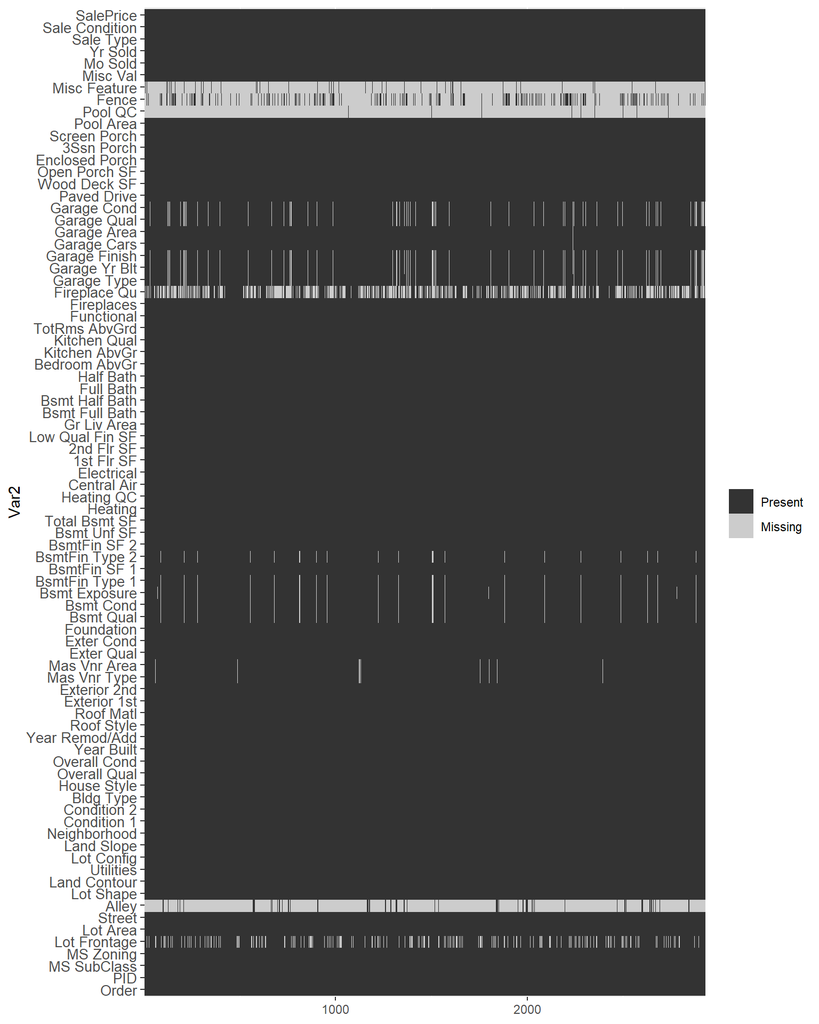

```r
AmesHousing::ames_raw %>%
  is.na() %>%
  reshape2::melt() %>%
  ggplot(aes(Var2, Var1, fill = value)) +
  geom_raster() +
  coord_flip() +
  scale_y_continuous(NULL, expand = c(0, 0)) +
  scale_fill_grey(name = "",
                  labels = c("Present", "Missing")) +
  theme(axis.text.y = element_text(size = 10))
```

```r
AmesHousing::ames_raw %>%
  filter(`Garage Cars` == 0 & `Garage Area` == 0) %>%
  select(starts_with("Garage"))
```

```
## # A tibble: 157 × 7
##    `Garage Type` `Garage Yr Blt` `Garage Finish` Garag…¹ Garag…² Garag…³ Garag…⁴
##    <chr>                   <int> <chr>             <int>   <int> <chr>   <chr>
##  1 <NA>                       NA <NA>                  0       0 <NA>    <NA>
##  2 <NA>                       NA <NA>                  0       0 <NA>    <NA>
##  3 <NA>                       NA <NA>                  0       0 <NA>    <NA>
##  4 <NA>                       NA <NA>                  0       0 <NA>    <NA>
##  5 <NA>                       NA <NA>                  0       0 <NA>    <NA>
##  6 <NA>                       NA <NA>                  0       0 <NA>    <NA>
##  7 <NA>                       NA <NA>                  0       0 <NA>    <NA>
##  8 <NA>                       NA <NA>                  0       0 <NA>    <NA>
##  9 <NA>                       NA <NA>                  0       0 <NA>    <NA>
## 10 <NA>                       NA <NA>                  0       0 <NA>    <NA>
## # … with 147 more rows, and abbreviated variable names ¹`Garage Cars`,
## #   ²`Garage Area`, ³`Garage Qual`, ⁴`Garage Cond`
```

we see that for houses whose have no Garage Cars and Garage Area, all related variables about Garage have missing values. So this missing is informative. All `NA` values for these variables may be imputed with a `"None"` category.

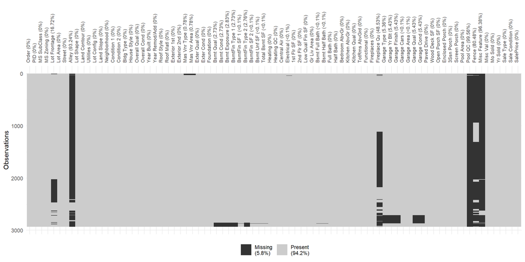

```r
visdat::vis_miss(AmesHousing::ames_raw, cluster = TRUE) +
  theme(
    axis.text.x.top = element_text(size = 8, angle = 90)
  )
```

### Imputation

Imputation is the process of replacing the missing values with the best guessed value.

We can perform imputation based on mean, median or mode (for categorical) of a feature. Also as an alternative, we can do model based imputation (KNN or tree based imputation).

#### Estimated Statistic based imputation

```r
ames_recipe  %>%
  step_impute_median(Gr_Liv_Area)
```

```
## Recipe
##
## Inputs:
##
##       role #variables
##    outcome          1
##  predictor         80
##
## Operations:
##
## Box-Cox transformation on all_outcomes()
## Median imputation for Gr_Liv_Area
```

#### KNN based imputation

KNN imputes missing values by identifying obsn with missing values at first and then identify other similar (based on other feature) obsns and use the values from these nearest neighbor to impute missing values.

In this method, missing value for a given obsn is treated as response and predicted by the avg (for quantitative values) or mode (for categorical values) of the k-nearest neighbors.

For small to medium sized data, knn imputation can be used. For large data, its better avoided.

```r
ames_recipe %>%
  step_impute_knn(all_predictors(), neighbors = 6)
```

```
## Recipe
##
## Inputs:
##
##       role #variables
##    outcome          1
##  predictor         80
##
## Operations:
##
## Box-Cox transformation on all_outcomes()
## K-nearest neighbor imputation for all_predictors()
```

#### Bagged tree based imputation

Bagged trees offer a compromise between predictive and computational burden.

It works similar as knn (ie. identify missing val as response)

```r
ames_recipe %>%
  step_impute_bag(all_predictors())
```

```
## Recipe
##
## Inputs:
##
##       role #variables
##    outcome          1
##  predictor         80
##
## Operations:
##
## Box-Cox transformation on all_outcomes()
## Bagged tree imputation for all_predictors()
```

## Feature Filtering

Features with zero variance and near zero variance should be removed. Because they provide no useful information for the model.

we can detect them in the following way

```r
caret::nearZeroVar(ames_train, saveMetrics = TRUE) %>%
  tibble::rownames_to_column() %>%
  filter(nzv) %>%
  DT::datatable()
```

|  | rowname | freqRatio | percentUnique | zeroVar | nzv |
| --- | --- | --- | --- | --- | --- |
| 1 | Street | 226.666666666667 | 0.0976085895558809 | False | True |
| 2 | Alley | 24.253164556962 | 0.146412884333821 | False | True |
| 3 | Land_Contour | 19.5 | 0.195217179111762 | False | True |
| 4 | Utilities | 1023 | 0.146412884333821 | False | True |
| 5 | Land_Slope | 22.1590909090909 | 0.146412884333821 | False | True |
| 6 | Condition_2 | 202.6 | 0.341630063445583 | False | True |
| 7 | Roof_Matl | 144.357142857143 | 0.390434358223524 | False | True |
| 8 | Bsmt_Cond | 20.2444444444444 | 0.292825768667643 | False | True |
| 9 | BsmtFin_Type_2 | 25.8529411764706 | 0.341630063445583 | False | True |
| 10 | BsmtFin_SF_2 | 453.25 | 9.37042459736457 | False | True |

[output cut: 11 more lines]

```r
ames_recipe %>%
  step_nzv(all_nominal())
```

```
## Recipe
##
## Inputs:
##
##       role #variables
##    outcome          1
##  predictor         80
##
## Operations:
##
## Box-Cox transformation on all_outcomes()
## Sparse, unbalanced variable filter on all_nominal()
```

## Numeric feature Engineering

### handling skewness

Models that have parametric distributional assumption can greatly affected by the skewness of numeric feature. So to minimize the skewness we can consider either box-cox transformation or yeo-johnson transformation.

```r
recipe(Sale_Price ~ ., data = ames_train) %>%
  step_YeoJohnson(all_numeric())
```

```
## Recipe
##
## Inputs:
##
##       role #variables
##    outcome          1
##  predictor         80
##
## Operations:
##
## Yeo-Johnson transformation on all_numeric()
```

### standardization

```r
ames_recipe %>%
  step_center(all_numeric(), -all_outcomes()) %>%
  step_scale(all_numeric(), -all_outcomes())
```

```
## Recipe
##
## Inputs:
##
##       role #variables
##    outcome          1
##  predictor         80
##
## Operations:
##
## Box-Cox transformation on all_outcomes()
## Centering for all_numeric(), -all_outcomes()
## Scaling for all_numeric(), -all_outcomes()
```

## Categorical feature engineering

### lumping (Reducing categories)

We can reduce the categories with few observations. Also for numeric feature, binning seems sometime very useful

```r
count(ames_train, Neighborhood) %>% arrange(n)
```

```
## # A tibble: 28 × 2
##    Neighborhood            n
##    <fct>               <int>
##  1 Landmark                1
##  2 Green_Hills             2
##  3 Greens                  3
##  4 Blueste                 8
##  5 Veenker                15
##  6 Northpark_Villa        17
##  7 Bloomington_Heights    18
##  8 Meadow_Village         22
##  9 Briardale              23
## 10 Clear_Creek            26
## # … with 18 more rows
```

```r
count(ames_train, Screen_Porch) %>% arrange(n)
```

```
## # A tibble: 95 × 2
##    Screen_Porch     n
##           <int> <int>
##  1           40     1
##  2           53     1
##  3           60     1
##  4           64     1
##  5           80     1
##  6           84     1
##  7           88     1
##  8           94     1
##  9           99     1
## 10          104     1
## # … with 85 more rows
```

However,

- Lumping should be done sparingly, as this sometimes may lead to loss in model performance
- **Tree based models often perform exceptionally well with high cardinality features and are not impacted by levels with few obsn**

```r
# lump levels for two features
lumping <- recipe(Sale_Price ~ ., data = ames_train) %>%
  step_other(Neighborhood, threshold = 0.01, other = "other") %>%
  step_other(Screen_Porch, threshold = 0.1, other = ">0")


# preping and baking
apply_2_training <- prep(lumping, training = ames_train) %>%
  bake(ames_train)
```

```r
count(apply_2_training, Neighborhood) %>% arrange(n)
```

```
## # A tibble: 22 × 2
##    Neighborhood                                n
##    <fct>                                   <int>
##  1 Meadow_Village                             22
##  2 Briardale                                  23
##  3 Clear_Creek                                26
##  4 South_and_West_of_Iowa_State_University    32
##  5 Stone_Brook                                40
##  6 Northridge                                 51
##  7 Timberland                                 52
##  8 other                                      64
##  9 Brookside                                  74
## 10 Crawford                                   75
## # … with 12 more rows
```

```r
count(apply_2_training, Screen_Porch) %>% arrange(n)
```

```
## # A tibble: 2 × 2
##   Screen_Porch     n
##   <fct>        <int>
## 1 >0             180
## 2 0             1869
```

### One-hot and dummy encoding

In one hot encoding we create separate variable for each level of a categorical variable. This is called **less than full rank encoding**, but this creates perfect multicollinearity which caused problems in some predictive modelling algorithm like OLS, neural net.

Alternatively, we can do dummy encoding, where we drop one of the levels and create one less variable than the number of categorical levels. This is **full-rank encoding**.

```r
recipe(Sale_Price ~ ., data = ames_train) %>%
  step_dummy(all_nominal(), one_hot = TRUE)
```

```
## Recipe
##
## Inputs:
##
##       role #variables
##    outcome          1
##  predictor         80
##
## Operations:
##
## Dummy variables from all_nominal()
```

### Label encoding and Ordinal encoding

Label encoding is the process of turning the categorical levels into integers. Now if the categorical variable is a factor with prespecified levels then numeric conversion will be in level order, otherwise it will be in alphabetic order.

```r
# original categories
ames_train %>% count(MS_SubClass)
```

```
## # A tibble: 15 × 2
##    MS_SubClass                                   n
##    <fct>                                     <int>
##  1 One_Story_1946_and_Newer_All_Styles         756
##  2 One_Story_1945_and_Older                     94
##  3 One_Story_with_Finished_Attic_All_Ages        4
##  4 One_and_Half_Story_Unfinished_All_Ages       13
##  5 One_and_Half_Story_Finished_All_Ages        203
##  6 Two_Story_1946_and_Newer                    404
##  7 Two_Story_1945_and_Older                     90
##  8 Two_and_Half_Story_All_Ages                  14
##  9 Split_or_Multilevel                          85
## 10 Split_Foyer                                  37
## 11 Duplex_All_Styles_and_Ages                   76
## 12 One_Story_PUD_1946_and_Newer                132
## 13 Two_Story_PUD_1946_and_Newer                 86
## 14 PUD_Multilevel_Split_Level_Foyer             12
## 15 Two_Family_conversion_All_Styles_and_Ages    43
```

```r
# label encoded
recipe(Sale_Price ~ . , data = ames_train) %>%
  step_integer(MS_SubClass) %>%
  prep(ames_train) %>%
  bake(ames_train) %>%
  count(MS_SubClass)
```

```
## # A tibble: 15 × 2
##    MS_SubClass     n
##          <dbl> <int>
##  1           1   756
##  2           2    94
##  3           3     4
##  4           4    13
##  5           5   203
##  6           6   404
##  7           7    90
##  8           8    14
##  9           9    85
## 10          10    37
## 11          11    76
## 12          12   132
## 13          14    86
## 14          15    12
## 15          16    43
```

Now we should be careful about label encoding unordered categorical features because most models will treat them as ordered numeric features. But label encoding is a natural choice for ordered factors, in which case it is known as Ordinal Encoding.

```r
# original category with natural order
ames_train %>% count(Overall_Qual)
```

```
## # A tibble: 10 × 2
##    Overall_Qual       n
##    <fct>          <int>
##  1 Very_Poor          3
##  2 Poor               9
##  3 Fair              33
##  4 Below_Average    147
##  5 Average          580
##  6 Above_Average    521
##  7 Good             408
##  8 Very_Good        242
##  9 Excellent         82
## 10 Very_Excellent    24
```

```r
# ordinal encoding
recipe(Sale_Price ~ ., data = ames_train) %>%
  step_integer(Overall_Qual) %>%
  prep(ames_train) %>%
  bake(ames_train) %>%
  count(Overall_Qual)
```

```
## # A tibble: 10 × 2
##    Overall_Qual     n
##           <dbl> <int>
##  1            1     3
##  2            2     9
##  3            3    33
##  4            4   147
##  5            5   580
##  6            6   521
##  7            7   408
##  8            8   242
##  9            9    82
## 10           10    24
```

## Dimension reduction

Its an alternative approach to automatically filter out non-informative approach.

```r
recipe(Sale_Price ~ ., data = ames_train) %>%
  step_center(all_numeric()) %>%
  step_scale(all_numeric()) %>%
  step_pca(all_numeric(), threshold = 0.95)
```

```
## Recipe
##
## Inputs:
##
##       role #variables
##    outcome          1
##  predictor         80
##
## Operations:
##
## Centering for all_numeric()
## Scaling for all_numeric()
## PCA extraction with all_numeric()
```

## Implementation

### Some sequential steps and tips

- If we need to use log or Box-Cox transformation, do not standardize data before the transformation which will generate negative values and log or box-cox transform can not handle neg values. Or, consider the Yeo-Johnson transformation.
- Standardized the numeric features first and then do the one hot or dummy encoding. Otherwise if we do dummy or one-hot encoding at first which will create sparse data and then do standardization, sparse data will be turned into dense data which may result into computational inefficiency.
- If we need to do lumping, do so before one-hot/dummy encoding
- We need to do dimension reduction (i.e. pca) on numeric feature and then do one-hot/dummy encoding on categorical feature.

So one suggested order of potential feature is,

1. Filter out zero or near zero variance features.
2. perform imputation if required
3. normalize and standardize the numeric feature.
4. Perform pca on numeric feature.
5. Perform dummy/one-hot encode.

## Data Leakage

Data Leakage occurs when information outside the training data is used to build the model and it occurs mostly in the pre-processing steps. To minimize this, feature engineering should be applied in isolation (i.e. independently) in each resampling iteration.

## Putting the process together

There are three main steps in creating and applying feature engineering with the `recipes` package, which is creating `recipe`, `prep` (prepare) on the training data and then `bake`.

> TODO: Need to understand more about `prep` and `bake`

For now we are using `{caret}`

```r
recipe(Sale_Price ~ ., data = ames_train) %>%
  step_integer(matches("Qual|Cond|QC|Qu")) %>%
  prep(ames_train) %>%
  bake(ames_train) %>%
  select(matches("Qual|Cond|QC|Qu")) %>%
  DT::datatable()
```

|  | Condition_1 | Condition_2 | Overall_Qual | Overall_Cond | Exter_Qual | Exter_Cond | Bsmt_Qual | Bsmt_Cond | Heating_QC | Second_Flr_SF | Low_Qual_Fin_SF | Kitchen_Qual | Fireplace_Qu | Garage_Qual | Garage_Cond | Pool_QC | Sale_Condition |
| --- | --- | --- | --- | --- | --- | --- | --- | --- | --- | --- | --- | --- | --- | --- | --- | --- | --- |
| 1 | 3 | 3 | 5 | 5 | 4 | 5 | 6 | 6 | 5 | 115 | 1 | 5 | 4 | 6 | 6 | 4 | 5 |
| 2 | 3 | 3 | 6 | 5 | 4 | 5 | 6 | 6 | 5 | 115 | 1 | 5 | 4 | 6 | 6 | 4 | 4 |
| 3 | 3 | 3 | 7 | 6 | 4 | 5 | 3 | 6 | 1 | 1 | 1 | 5 | 4 | 6 | 6 | 4 | 5 |
| 4 | 3 | 3 | 6 | 5 | 4 | 5 | 3 | 6 | 5 | 1 | 1 | 5 | 4 | 6 | 6 | 4 | 5 |
| 5 | 2 | 3 | 5 | 5 | 4 | 2 | 6 | 6 | 5 | 1 | 1 | 5 | 4 | 6 | 6 | 4 | 5 |
| 6 | 6 | 3 | 6 | 5 | 4 | 5 | 4 | 4 | 5 | 125 | 1 | 5 | 4 | 6 | 6 | 4 | 5 |
| 7 | 3 | 3 | 5 | 5 | 4 | 3 | 6 | 6 | 5 | 1 | 1 | 5 | 4 | 6 | 6 | 4 | 5 |
| 8 | 3 | 3 | 5 | 8 | 4 | 3 | 6 | 6 | 1 | 1 | 1 | 5 | 4 | 6 | 6 | 4 | 5 |
| 9 | 3 | 3 | 5 | 6 | 4 | 5 | 6 | 6 | 5 | 1 | 1 | 5 | 4 | 4 | 4 | 4 | 1 |
| 10 | 3 | 3 | 5 | 5 | 4 | 5 | 6 | 6 | 5 | 1 | 1 | 5 | 4 | 6 | 6 | 4 | 5 |

[output cut: 2039 more lines]

> I am not sure why we are doing ordinal encoding before the pca, I though we would do pca on numeric feature first and then do ordinal encoding or dummy/one hot encoding.

Any way back to the usual flow,

```r
blueprint <- recipe(Sale_Price ~ ., data = ames_train) %>%
  step_nzv(all_nominal()) %>%
  step_integer(matches("Qual|Cond|QC|Qu")) %>%
  step_center(all_numeric(), -all_outcomes()) %>%
  step_scale(all_numeric(), -all_outcomes()) %>%
  step_dummy(all_nominal(), -all_outcomes(), one_hot = TRUE)
```

```r
# specify the resampling plan
cv <- trainControl(
  method = "repeatedcv",
  number = 10,
  repeats = 5
)
```

```r
# hyper param grid
hyper_grid <- expand.grid(k = seq(2, 25, by = 1))
```

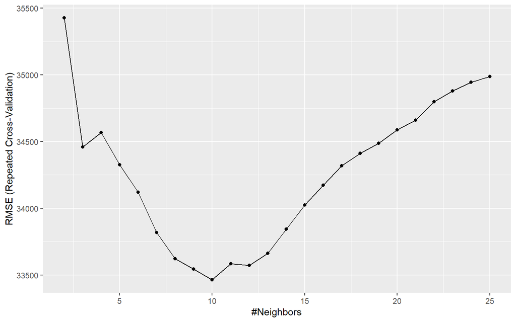

```r
# tune a knn model using grid search
xfun::cache_rds({
  # Tune a knn model using the grid search
  knn_fit2 <- caret::train(
    blueprint,
    data = ames_train,
    method = "knn",
    trControl = cv,
    tuneGrid = hyper_grid,
    metric = "RMSE"
)

 knn_fit2

 ggplot(knn_fit2)

}, dir = here::here("R/cache", "chap_03_cache_"), file = "knn.rds")
```